# Good plot / Bad plot - Spotify Plays

Evan Rank

3/10/2021

## Introduction

My goal is to present a single dataset twice, one to make an example of how *not* to do a plot and the other as an example of how a publication-quality figure should be presented. The data used in this exercise is publicly available data from Spotify of over 30,000 songs classified by artist, genre, and several other factors. The data was assembled from TidyTuesday on Github, but was originally sourced from Spotify’s web API.

## Load Libraries

```r
library(here)
library(tidyverse)
library(tidytuesdayR) #Great source of free data, even outside of Tidy Tuesday submissions
```

## Load in Data

```r
spotify_songs <- readr::read_csv('https://raw.githubusercontent.com/rfordatascience/tidytuesday/master/data/2020/2020-01-21/spotify_songs.csv') %>%
write_csv(here("Week_7","Data", "spotify_songs.csv")) #in case we need to access data outside the R package

view(spotify_songs)
```

## “Bad” Plot

This plot is poor in both viewing and in data selection. The tracks used to determine the “popular” artists are only the first 6 unique popular songs.

The graph is in the default ugly gray, the title is poor, and there is no label for the y axis.

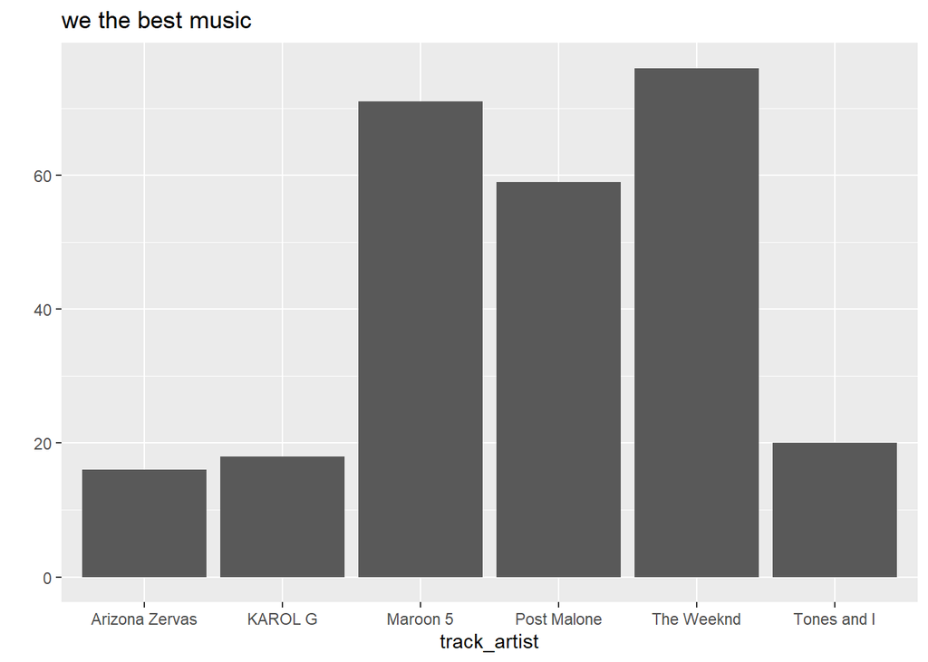

```r
Bad_Plot_Spotify <- spotify_songs %>%
  filter(track_artist %in% c("Tones and I", "Arizona Zervas", "KAROL G", "Maroon 5", "The Weeknd", "Post Malone")) %>%
  ggplot(aes(x=track_artist))+
  geom_bar()+
  labs(title = "we the best music",
       y="")

Bad_Plot_Spotify
```

## “Good” Plot

Instead of selecting the “top” artists by only a few songs, I determined them by the tracks with a score of “95” and above, with “100” being the best possible score. This should give us a greater sample size of popular tracks to which artists were most influential. The genre was also included.

Additional information was added to inform the viewer of popular genres as well as artists. Colors don’t clash, and labeling is as concise and accurate as possible.

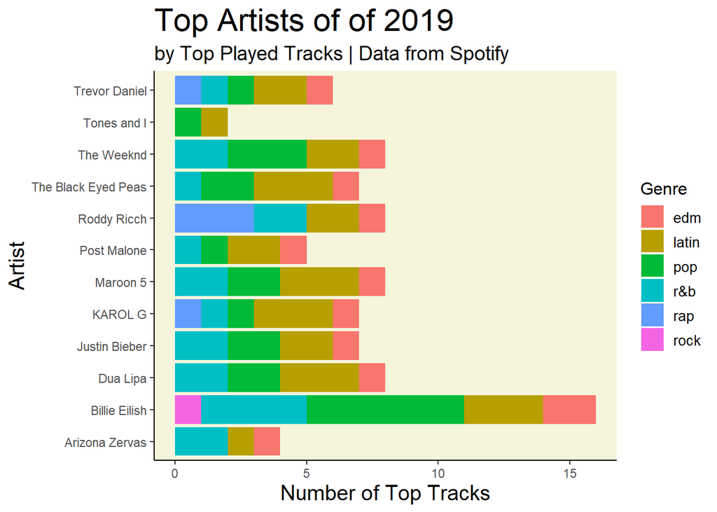

```r
Good_Plot_Spotify <- spotify_songs %>%
  filter(track_popularity %in% c(100,99,98,97,96,95)) %>%
  ggplot(aes(y=track_artist, fill=playlist_genre))+
  geom_bar()+ #Data frame suited for "counts"
   labs(title = "Top Artists of of 2019", #source was not specific on date, but the original blog post for the data was published at the tail end of 2019.
        subtitle = "by Top Played Tracks | Data from Spotify",
        x="Number of Top Tracks",
        y="Artist",
        fill = "Genre")+
  theme_classic()+ #Built in theme for removing gridlines
  theme(plot.title = element_text(size = 22), #Custom text size and colors from here on
        plot.subtitle= element_text (size =14),
    axis.title=element_text(size = 15),
    legend.title=element_text(size=12),
panel.background=element_rect(fill="beige"),
legend.text=element_text(size=10))+
  scale_color_viridis_d() #colorblind friendly color scheme

Good_Plot_Spotify
```